# Assignment 8: Visualization - Making a bar race

Return Here: README

*How to do it?*:

- Open the Rmarkdown file of this assignment (link) in Rstudio.
- Right under each **question**, insert a code chunk (you can use the hotkey `Ctrl + Alt + I` to add a code chunk) and code the solution for the question.
- `Knit` the rmarkdown file (hotkey: `Ctrl + Alt + K`) to export an html.
- Publish the html file to your Githiub Page.

*Submission*: Submit the link on Github of the assignment to Canvas

1. Install two packages `gganimate` and `gifski` then restart Rstudio. Using the `Adult Census Income` data, make an animation using `geom_point` and `transition_states`.

```r
library("tidyverse")
library("gganimate")
library("gifski")
```

```r
library("ggplot2")
df = read_csv("Data/adult_census.csv")
```

```r
df %>% names
```

```
##  [1] "age"            "workclass"      "fnlwgt"         "education"
##  [5] "education.num"  "marital.status" "occupation"     "relationship"
##  [9] "race"           "sex"            "capital.gain"   "capital.loss"
## [13] "hours.per.week" "native.country" "income"
```

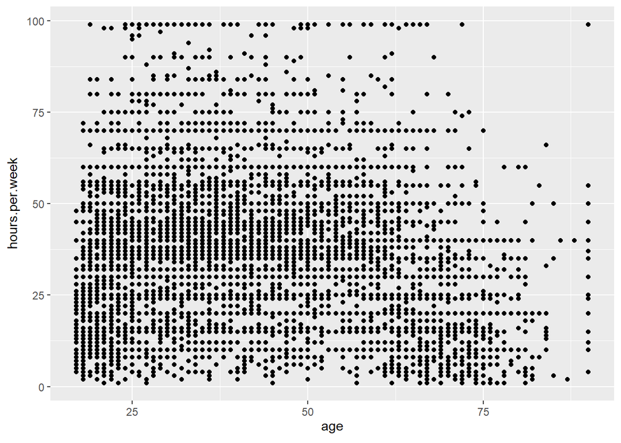

```r
# Its going to take all the points and translation them, its pretty cool
g = df %>% ggplot() + geom_point(mapping = aes(age, hours.per.week)) + transition_states(income)

animate(g)
```

2. Using the `Adult Census Income` data, make an animation using `geom_bar` and `transition_states`.

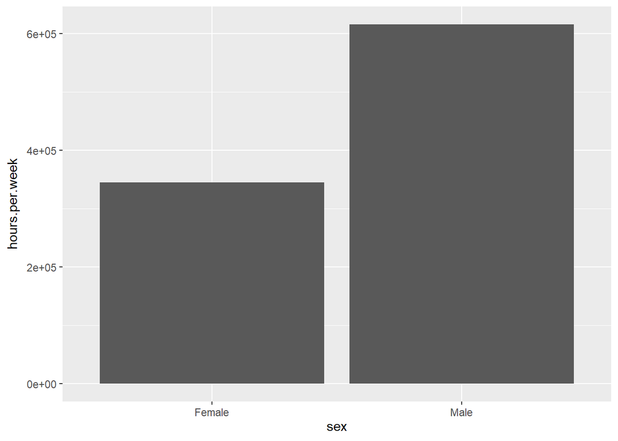

```r
# Going to just build a bars and then update the bars
g = df %>% ggplot() + geom_col(mapping = aes(sex, hours.per.week)) + transition_states(income)

animate(g)
```

3. Use the WHO’s dataset at [this link](https://covid19.who.int/WHO-COVID-19-global-data.csv). Make a top-10 bar race by months between countries on the number of deaths by Covid 19 in 2021.

```r
df = read_csv("Data/WHO-COVID-19-global-data.csv")
```

```r
df %>% names
```

```
## [1] "Date_reported"     "Country_code"      "Country"
## [4] "WHO_region"        "New_cases"         "Cumulative_cases"
## [7] "New_deaths"        "Cumulative_deaths"
```

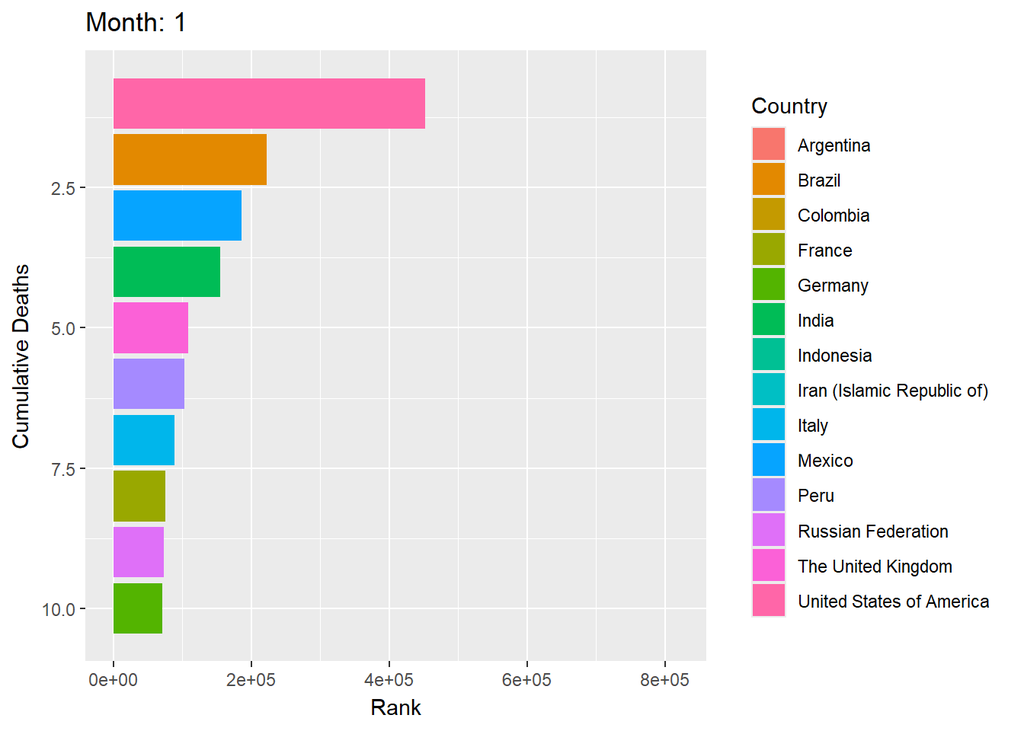

```r
# First filter to 2021, then mutate to get month column
# Then group by month and country, then get the cumulative death counts
# Then group by month, and get your rank variable and then filter to top 10
d2 = df %>%
  filter(Date_reported > "2020-12-31" & Date_reported < "2022-01-01") %>%
  mutate(month = month(Date_reported)) %>%
  group_by(month, Country) %>%
  summarise(Cumulative_deaths = max(Cumulative_deaths, na.rm = TRUE)) %>%
  group_by(month) %>%
  mutate(rank = rank(-Cumulative_deaths)) %>%
  filter(rank <= 10)


g = d2 %>% ggplot() +
  geom_col(mapping = aes(y = rank, x = Cumulative_deaths, fill = Country), orientation = "y") + scale_y_reverse() +
# need orientation = y for some reason to tell the bars to go left to right
  transition_states(month) +
  labs(x = "Rank",
       y = "Cumulative Deaths",
       title = "Month: {closest_state}")

animate(g)
```

4. Make a bar race using a dataset of your own interest. You may use the dataset that we use in class (https://covidtracking.com/data/download/all-states-history.csv) but you should make a different bar racev from ones in the slides.

```r
df = read_csv("Data/imdb_top_1000.csv")
# From AI its so I can get the genre to like 14 genres instead of so many
df$Main_Genre = str_extract(df$Genre, "^[^,]+")
df %>% names
```

```
##  [1] "Poster_Link"   "Series_Title"  "Released_Year" "Certificate"
##  [5] "Runtime"       "Genre"         "IMDB_Rating"   "Overview"
##  [9] "Meta_score"    "Director"      "Star1"         "Star2"
## [13] "Star3"         "Star4"         "No_of_Votes"   "Gross"
## [17] "Main_Genre"
```

```r
# So
d2 = df %>%
  # Parse number to get it into a number
  mutate(Released_Year = parse_number(Released_Year)) %>%
  filter(Released_Year >= 2000) %>%
  group_by(Released_Year, Main_Genre) %>%
  summarise(Gross = max(Gross, na.rm = TRUE)) %>%
  filter(Gross > 0) %>%
  group_by(Released_Year) %>%
  mutate(rank = rank(-Gross)) %>%
  filter(rank <= 10)
```

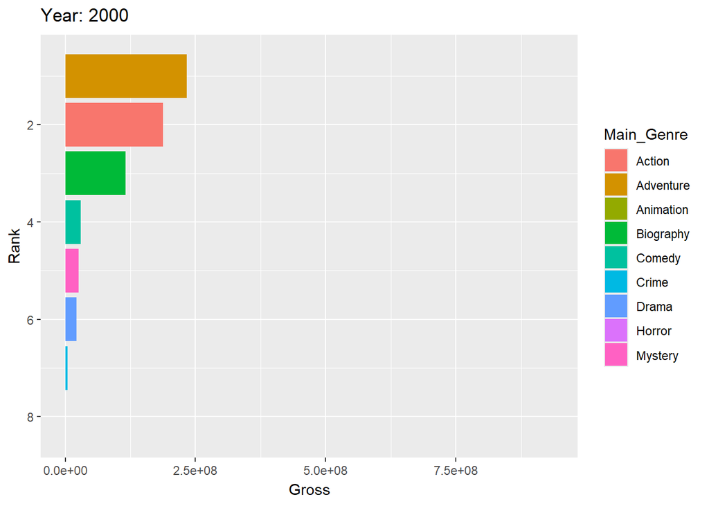

```r
g = d2 %>% ggplot() +
  geom_col(mapping = aes(y = rank, x = Gross, fill = Main_Genre), orientation = "y") +
  # to flip the ranking
  scale_y_reverse() +
  transition_states(Released_Year) +
  labs(x = "Gross",
       y = "Rank",
       title = "Year: {closest_state}")

animate(g)
```